# Case study on Bank Personal Loan Campaign

# Data Description:

The file Bank.xls contains data on 5000 customers. The data include customer demographic information (age, income, etc.), the customer's relationship with the bank (mortgage, securities account, etc.), and the customer response to the last personal loan campaign (Personal Loan). Among these 5000 customers, only 480 (= 9.6%) accepted the personal loan that was offered to them in the earlier campaign.

# Domain:

Banking

# Context:

This case is about a bank (Thera Bank) whose management wants to explore ways of converting its liability customers to personal loan customers (while retaining them as depositors). A campaign that the bank ran last year for liability customers showed a healthy conversion rate of over 9% success. This has encouraged the retail marketing department to devise campaigns with better target marketing to increase the success ratio with a minimal budget.

# Objective:

The classification goal is to predict the likelihood of a liability customer buying personal loans.

# Attribute Information:

1. ID: Customer ID
2. Age: Customer's age in completed years
3. Experience: #years of professional experience
4. Income: Annual income of the customer in dollars
5. ZIP Code: Home Address ZIP code.
6. Family: Family size of the customer
7. CCAvg: Avg. spending on credit cards per month ($000)
8. Education: Education Level. 1: Undergrad; 2: Graduate; 3: Advanced/Professional
9. Mortgage: Value of house mortgage if any. ($000)
10. Personal Loan: Did this customer accept the personal loan offered in the last campaign?
11. Securities Account: Does the customer have a securities account with the bank?
12. CD Account: Does the customer have a certificate of deposit (CD) account with the bank?
13. Online: Does the customer use internet banking facilities?
14. Credit card: Does the customer use a credit card issued by the bank?

```python
#importing required packages
%matplotlib inline
import numpy as np
import pandas as pd
import matplotlib.pyplot as plt
import seaborn as sns
from sklearn.model_selection import train_test_split
from sklearn.linear_model import LogisticRegression
from imblearn.over_sampling import SMOTE
from imblearn.under_sampling import NearMiss
from sklearn.naive_bayes import GaussianNB
from sklearn.neighbors import KNeighborsClassifier
from sklearn.ensemble import RandomForestClassifier
from sklearn.tree import DecisionTreeClassifier
from sklearn.metrics import confusion_matrix,precision_score,accuracy_score,recall_score,f1_score,roc_auc_score, roc_curve,classification_report
import warnings
warnings.filterwarnings('ignore')
```

```python
#reading loan dataset
loan = pd.read_csv("Bank_Personal_Loan_Modelling.csv")
```

```python
#Checking shape of dataset
loan.shape
```

```
(5000, 14)
```

```python
#checking dataset fields and records
loan.head(100)
```

|  | ID | Age | Experience | Income | ZIP Code | Family | CCAvg | Education | Mortgage | Personal Loan | Securities Account | CD Account | Online | CreditCard |
| --- | --- | --- | --- | --- | --- | --- | --- | --- | --- | --- | --- | --- | --- | --- |
| 0 | 1 | 25 | 1 | 49 | 91107 | 4 | 1.6 | 1 | 0 | 0 | 1 | 0 | 0 | 0 |
| 1 | 2 | 45 | 19 | 34 | 90089 | 3 | 1.5 | 1 | 0 | 0 | 1 | 0 | 0 | 0 |
| 2 | 3 | 39 | 15 | 11 | 94720 | 1 | 1.0 | 1 | 0 | 0 | 0 | 0 | 0 | 0 |
| 3 | 4 | 35 | 9 | 100 | 94112 | 1 | 2.7 | 2 | 0 | 0 | 0 | 0 | 0 | 0 |
| 4 | 5 | 35 | 8 | 45 | 91330 | 4 | 1.0 | 2 | 0 | 0 | 0 | 0 | 0 | 1 |
| ... | ... | ... | ... | ... | ... | ... | ... | ... | ... | ... | ... | ... | ... | ... |
| 95 | 96 | 38 | 12 | 48 | 95617 | 4 | 0.2 | 3 | 0 | 0 | 0 | 0 | 1 | 0 |
| 96 | 97 | 41 | 15 | 80 | 95014 | 1 | 5.2 | 1 | 0 | 0 | 0 | 0 | 0 | 0 |
| 97 | 98 | 54 | 28 | 161 | 92121 | 1 | 2.9 | 1 | 0 | 0 | 0 | 0 | 1 | 0 |
| 98 | 99 | 49 | 23 | 94 | 92374 | 1 | 0.3 | 1 | 0 | 0 | 0 | 0 | 1 | 0 |
| 99 | 100 | 66 | 41 | 15 | 91711 | 3 | 0.1 | 3 | 0 | 0 | 0 | 0 | 1 | 0 |

100 rows × 14 columns

```python
#Reshuffling Fields
loan=loan[['ID','Age','Experience','Income','ZIP Code','Family','CCAvg','Education','Mortgage','Securities Account',
                     'CD Account','Online','CreditCard','Personal Loan']]
```

```python
loan.head(2)
```

|  | ID | Age | Experience | Income | ZIP Code | Family | CCAvg | Education | Mortgage | Securities Account | CD Account | Online | CreditCard | Personal Loan |
| --- | --- | --- | --- | --- | --- | --- | --- | --- | --- | --- | --- | --- | --- | --- |
| 0 | 1 | 25 | 1 | 49 | 91107 | 4 | 1.6 | 1 | 0 | 1 | 0 | 0 | 0 | 0 |
| 1 | 2 | 45 | 19 | 34 | 90089 | 3 | 1.5 | 1 | 0 | 1 | 0 | 0 | 0 | 0 |

```python
loan.loc[:,['ZIP Code']]
```

|  | ZIP Code |
| --- | --- |
| 0 | 91107 |
| 1 | 90089 |
| 2 | 94720 |
| 3 | 94112 |
| 4 | 91330 |
| ... | ... |
| 4995 | 92697 |
| 4996 | 92037 |
| 4997 | 93023 |
| 4998 | 90034 |
| 4999 | 92612 |

5000 rows × 1 columns

```python
loan['ZIP Code'].value_counts().unique
```

```
<bound method Series.unique of 94720    169
94305    127
95616    116
90095     71
93106     57
        ...
96145      1
94970      1
94598      1
90068      1
94087      1
Name: ZIP Code, Length: 467, dtype: int64>
```

### ZIP Code Analysis

```python
zip_dict = {91107:"Pasadena",
90089:"Los Angeles",
94720:"Berkeley",
94112:"San Francisco",
91330:"Northridge",
92121:"San Diego",
91711:"Claremont",
93943:"Monterey",
93023:"Ojai",
94710:"Berkeley",
90277:"Redondo Beach",
93106:"Santa Barbara",
94920:"Belvedere Tiburon",
91741:"Glendora",
95054:"Santa Clara",
95010:"Capitola",
94305:"Stanford",
91604:"Studio City",
94015:"Daly City",
90095:"Los Angeles",
91320:"Newbury Park",
95521:"Arcata",
95064:"Santa Cruz",
90064:"Los Angeles",
94539:"Fremont",
94104:"San Francisco",
94117:"San Francisco",
94801:"Richmond",
94035:"Mountain View",
92647:"Huntington Beach",
95814:"Sacramento",
94114:"San Francisco",
94115:"San Francisco",
92672:"San Clemente",
94122:"San Francisco",
90019:"Los Angeles",
95616:"Davis",
94065:"Redwood City",
95014:"Cupertino",
91380:"Santa Clarita",
95747:"Roseville",
92373:"Redlands",
92093:"La Jolla",
94005:"Brisbane",
90245:"El Segundo",
95819:"Sacramento",
94022:"Los Altos",
90404:"Santa Monica",
93407:"San Luis Obispo",
94523:"Pleasant Hill",
90024:"Los Angeles",
91360:"Thousand Oaks",
95670:"Rancho Cordova",
95123:"San Jose",
90045:"Los Angeles",
91335:"Reseda",
93907:"Salinas",
92007:"Cardiff By The Sea",
94606:"Oakland",
94611:"Oakland",
94901:"San Rafael",
92220:"Banning",
93305:"Bakersfield",
95134:"San Jose",
94612:"Oakland",
92507:"Riverside",
91730:"Rancho Cucamonga",
94501:"Alameda",
94303:"Palo Alto",
94105:"San Francisco",
94550:"Livermore",
92612:"Irvine",
95617:"Davis",
92374:"Redlands",
94080:"South San Francisco",
94608:"Emeryville",
93555:"Ridgecrest",
93311:"Bakersfield",
94704:"Berkeley",
92717:"FPO San Francisco",
92037:"La Jolla",
95136:"San Jose",
94542:"Hayward",
94143:"San Francisco",
91775:"San Gabriel",
92703:"Santa Ana",
92354:"Loma Linda",
92024:"Encinitas",
92831:"Fullerton",
92833:"Fullerton",
94304:"Palo Alto",
90057:"Los Angeles",
92130:"San Diego",
91301:"Agoura Hills",
92096:"San Marcos",
92646:"Huntington Beach",
92182:"San Diego",
92131:"San Diego",
93720:"Fresno",
90840:"Long Beach",
95035:"Milpitas",
93010:"Camarillo",
94928:"Rohnert Park",
95831:"Sacramento",
91770:"Rosemead",
90007:"Los Angeles",
94102:"San Francisco",
91423:"Sherman Oaks",
93955:"Seaside",
94107:"San Francisco",
92834:"Fullerton",
93117:"Goleta",
94551:"Livermore",
94596:"Walnut Creek",
94025:"Menlo Park",
94545:"Hayward",
95053:"Santa Clara",
90036:"Los Angeles",
91125:"Pasadena",
95120:"San Jose",
94706:"Albany",
95827:"Sacramento",
90503:"Torrance",
90250:"Hawthorne",
95817:"Sacramento",
95503:"Eureka",
93111:"Santa Barbara",
94132:"San Francisco",
95818:"Sacramento",
91942:"La Mesa",
90401:"Santa Monica",
93524:"Edwards",
95133:"San Jose",
92173:"San Ysidro",
94043:"Mountain View",
92521:"Riverside",
92122:"San Diego",
93118:"Goleta",
92697:"Irvine",
94577:"San Leandro",
91345:"Mission Hills",
94123:"San Francisco",
92152:"San Diego",
91355:"Valencia",
94609:"Oakland",
94306:"Palo Alto",
96150:"South Lake Tahoe",
94110:"San Francisco",
94707:"Berkeley",
91326:"Porter Ranch",
90291:"Venice",
92807:"Anaheim",
95051:"Santa Clara",
94085:"Sunnyvale",
92677:"Laguna Niguel",
92614:"Irvine",
92626:"Costa Mesa",
94583:"San Ramon",
92103:"San Diego",
92691:"Mission Viejo",
92407:"San Bernardino",
90504:"Torrance",
94002:"Belmont",
95039:"Moss Landing",
94063:"Redwood City",
94923:"Bodega Bay",
95023:"Hollister",
90058:"Los Angeles",
92126:"San Diego",
94118:"San Francisco",
90029:"Los Angeles",
92806:"Anaheim",
94806:"San Pablo",
92110:"San Diego",
94536:"Fremont",
90623:"La Palma",
92069:"San Marcos",
92843:"Garden Grove",
92120:"San Diego",
95605:"West Sacramento",
90740:"Seal Beach",
91207:"Glendale",
95929:"Chico",
93437:"Lompoc",
90630:"Cypress",
90034:"Los Angeles",
90266:"Manhattan Beach",
95630:"Folsom",
93657:"Sanger",
92038:"La Jolla",
91304:"Canoga Park",
92606:"Irvine",
92192:"San Diego",
90745:"Carson",
95060:"Santa Cruz",
94301:"Palo Alto",
92692:"Mission Viejo",
92101:"San Diego",
94610:"Oakland",
90254:"Hermosa Beach",
94590:"Vallejo",
92028:"Fallbrook",
92054:"Oceanside",
92029:"Escondido",
93105:"Santa Barbara",
91941:"La Mesa",
92346:"Highland",
94402:"San Mateo",
94618:"Oakland",
94904:"Greenbrae",
9307:"Milwaukee",
95482:"Ukiah",
91709:"Chino Hills",
91311:"Chatsworth",
94509:"Antioch",
92866:"Orange",
91745:"Hacienda Heights",
94111:"San Francisco",
94309:"Palo Alto",
90073:"Los Angeles",
92333:"Fawnskin",
90505:"Torrance",
94998:"Novato",
94086:"Sunnyvale",
94709:"Berkeley",
95825:"Sacramento",
90509:"Torrance",
93108:"Santa Barbara",
94588:"Pleasanton",
91706:"Baldwin Park",
92109:"San Diego",
92068:"San Luis Rey",
95841:"Sacramento",
92123:"San Diego",
91342:"Sylmar",
90232:"Culver City",
92634:"Fullerton",
91006:"Arcadia",
91768:"Pomona",
90028:"Los Angeles",
92008:"Carlsbad",
95112:"San Jose",
92154:"San Diego",
92115:"San Diego",
92177:"San Diego",
90640:"Montebello",
94607:"Oakland",
92780:"Tustin",
90009:"Los Angeles",
92518:"March Air Reserve Base",
91007:"Arcadia",
93014:"Carpinteria",
94024:"Los Altos",
90027:"Los Angeles",
95207:"Stockton",
90717:"Lomita",
94534:"Fairfield",
94010:"Burlingame",
91614:"Studio City",
94234:"Sacramento",
90210:"Beverly Hills",
95020:"Gilroy",
92870:"Placentia",
92124:"San Diego",
90049:"Los Angeles",
94521:"Concord",
95678:"Roseville",
95045:"San Juan Bautista",
92653:"Laguna Hills",
92821:"Brea",
90025:"Los Angeles",
92835:"Fullerton",
91910:"Chula Vista",
94701:"Berkeley",
91129:"Pasadena",
94960:"San Anselmo",
91902:"Bonita",
90033:"Los Angeles",
95621:"Citrus Heights",
90037:"Los Angeles",
90005:"Los Angeles",
93940:"Monterey",
91109:"Pasadena",
93009:"Ventura",
93561:"Tehachapi",
95126:"San Jose",
94109:"San Francisco",
93107:"Santa Barbara",
94591:"Vallejo",
92251:"Imperial",
92648:"Huntington Beach",
92709:"Irvine",
1754:"Monterey Park",
92009:"Carlsbad",
96064:"Montague",
91103:"Pasadena",
91030:"South Pasadena",
90066:"Los Angeles",
95403:"Santa Rosa",
91016:"Monrovia",
95348:"Merced",
91950:"National City",
95822:"Sacramento",
94538:"Fremont",
92056:"Oceanside",
93063:"Simi Valley",
91040:"Sunland",
92661:"Newport Beach",
94061:"Redwood City",
95758:"Elk Grove",
96091:"Trinity Center",
94066:"San Bruno",
94939:"Larkspur",
95138:"San Jose",
95762:"El Dorado Hills",
92064:"Poway",
94708:"Berkeley",
92106:"San Diego",
92116:"San Diego",
91302:"Calabasas",
90048:"Los Angeles",
90405:"Santa Monica",
92325:"Crestline",
91116:"Pasadena",
92868:"Orange",
90638:"La Mirada",
90747:"Carson",
93611:"Clovis",
95833:"Sacramento",
91605:"North Hollywood",
92675:"San Juan Capistrano",
90650:"Norwalk",
95820:"Sacramento",
90018:"Los Angeles",
93711:"Fresno",
95973:"Chico",
92886:"Yorba Linda",
95812:"Sacramento",
91203:"Glendale",
91105:"Pasadena",
95008:"Campbell",
90016:"Los Angeles",
90035:"Los Angeles",
92129:"San Diego",
90720:"Los Alamitos",
94949:"Novato",
90041:"Los Angeles",
95003:"Aptos",
95192:"San Jose",
91101:"Pasadena",
94126:"San Francisco",
90230:"Culver City",
93101:"Santa Barbara",
91365:"Woodland Hills",
91367:"Woodland Hills",
91763:"Montclair",
92660:"Newport Beach",
92104:"San Diego",
91361:"Westlake Village",
90011:"Los Angeles",
90032:"Los Angeles",
95354:"Modesto",
94546:"Castro Valley",
92673:"San Clemente",
95741:"Rancho Cordova",
95351:"Modesto",
92399:"Yucaipa",
90274:"Palos Verdes Peninsula",
94087:"Sunnyvale",
90044:"Los Angeles",
94131:"San Francisco",
94124:"San Francisco",
95032:"Los Gatos",
90212:"Beverly Hills",
93109:"Santa Barbara",
94019:"Half Moon Bay",
95828:"Sacramento",
90086:"Los Angeles",
94555:"Fremont",
93033:"Oxnard",
93022:"Oak View",
91343:"North Hills",
91911:"Chula Vista",
94803:"El Sobrante",
94553:"Martinez",
95211:"Stockton",
90304:"Inglewood",
92084:"Vista",
90601:"Whittier",
92704:"Santa Ana",
92350:"Loma Linda",
94705:"Berkeley",
93401:"San Luis Obispo",
90502:"Torrance",
94571:"Rio Vista",
95070:"Saratoga",
92735:"Santa Ana",
95037:"Morgan Hill",
95135:"San Jose",
94028:"Portola Valley",
96003:"Redding",
91024:"Sierra Madre",
90065:"Los Angeles",
95405:"Santa Rosa",
95370:"Sonora",
93727:"Fresno",
92867:"Orange",
95821:"Sacramento",
94566:"Pleasanton",
95125:"San Jose",
94526:"Danville",
94604:"Oakland",
96008:"Bella Vista",
93065:"Simi Valley",
96001:"Redding",
95006:"Boulder Creek",
90639:"La Mirada",
92630:"Lake Forest",
95307:"Ceres",
91801:"Alhambra",
94302:"Palo Alto",
91710:"Chino",
93950:"Pacific Grove",
90059:"Los Angeles",
94108:"San Francisco",
94558:"Napa",
93933:"Marina",
92161:"San Diego",
94507:"Alamo",
94575:"Moraga",
95449:"Hopland",
93403:"San Luis Obispo",
93460:"Santa Ynez",
95005:"Ben Lomond",
93302:"Bakersfield",
94040:"Mountain View",
91401:"Van Nuys",
95816:"Sacramento",
92624:"Capistrano Beach",
95131:"San Jose",
94965:"Sausalito",
91784:"Upland",
91765:"Diamond Bar",
90280:"South Gate",
95422:"Clearlake",
95518:"Arcata",
95193:"San Jose",
92694:"Ladera Ranch",
90275:"Rancho Palos Verdes",
90272:"Pacific Palisades",
91791:"West Covina",
92705:"Santa Ana",
91773:"San Dimas",
93003:"Ventura",
90755:"Signal Hill",
96145:"Tahoe City",
94703:"Berkeley",
96094:"Weed",
95842:"Sacramento",
94116:"San Francisco",
90068:"Los Angeles",
94970:"Stinson Beach",
90813:"Long Beach",
94404:"San Mateo",
94598:"Walnut Creek",
96651:"Rudno nad Hronom",
90071:"Los Angeles",
}
```

```python
loan['City'] =loan['ZIP Code'].map(zip_dict)
```

```python
loan.head()
```

|  | ID | Age | Experience | Income | ZIP Code | Family | CCAvg | Education | Mortgage | Securities Account | CD Account | Online | CreditCard | Personal Loan | City |
| --- | --- | --- | --- | --- | --- | --- | --- | --- | --- | --- | --- | --- | --- | --- | --- |
| 0 | 1 | 25 | 1 | 49 | 91107 | 4 | 1.6 | 1 | 0 | 1 | 0 | 0 | 0 | 0 | Pasadena |
| 1 | 2 | 45 | 19 | 34 | 90089 | 3 | 1.5 | 1 | 0 | 1 | 0 | 0 | 0 | 0 | Los Angeles |
| 2 | 3 | 39 | 15 | 11 | 94720 | 1 | 1.0 | 1 | 0 | 0 | 0 | 0 | 0 | 0 | Berkeley |
| 3 | 4 | 35 | 9 | 100 | 94112 | 1 | 2.7 | 2 | 0 | 0 | 0 | 0 | 0 | 0 | San Francisco |
| 4 | 5 | 35 | 8 | 45 | 91330 | 4 | 1.0 | 2 | 0 | 0 | 0 | 0 | 1 | 0 | Northridge |

```python
#Checking null values
loan.isnull().sum()
```

```
ID                    0
Age                   0
Experience            0
Income                0
ZIP Code              0
Family                0
CCAvg                 0
Education             0
Mortgage              0
Securities Account    0
CD Account            0
Online                0
CreditCard            0
Personal Loan         0
City                  5
dtype: int64
```

# NA Value Treatment

```python
loan[loan['City'].isna()]
```

|  | ID | Age | Experience | Income | ZIP Code | Family | CCAvg | Education | Mortgage | Securities Account | CD Account | Online | CreditCard | Personal Loan | City |
| --- | --- | --- | --- | --- | --- | --- | --- | --- | --- | --- | --- | --- | --- | --- | --- |
| 711 | 712 | 62 | 37 | 83 | 91754 | 3 | 1.8 | 2 | 187 | 1 | 0 | 0 | 0 | 0 | NaN |
| 1300 | 1301 | 61 | 36 | 23 | 91754 | 2 | 0.5 | 2 | 103 | 0 | 0 | 1 | 0 | 0 | NaN |
| 2057 | 2058 | 37 | 12 | 125 | 91754 | 2 | 3.9 | 1 | 0 | 0 | 0 | 1 | 1 | 0 | NaN |
| 2129 | 2130 | 35 | 10 | 58 | 91754 | 4 | 0.7 | 3 | 232 | 0 | 0 | 0 | 0 | 0 | NaN |
| 3043 | 3044 | 47 | 22 | 42 | 91754 | 3 | 2.7 | 2 | 0 | 0 | 0 | 1 | 1 | 0 | NaN |

```python
loan.loc[711,'City']="Monterey Park"
loan.loc[1300,'City']="Monterey Park"
loan.loc[2057,'City']="Monterey Park"
loan.loc[2129,'City']="Monterey Park"
loan.loc[3043,'City']="Monterey Park"
```

```python
loan.isna().sum()
```

```
ID                    0
Age                   0
Experience            0
Income                0
ZIP Code              0
Family                0
CCAvg                 0
Education             0
Mortgage              0
Securities Account    0
CD Account            0
Online                0
CreditCard            0
Personal Loan         0
City                  0
dtype: int64
```

```python
loan['City'].value_counts()
```

```
Los Angeles      375
San Diego        269
San Francisco    257
Berkeley         241
Sacramento       148
                ...
Milwaukee          1
Tahoe City         1
Sierra Madre       1
Sausalito          1
Stinson Beach      1
Name: City, Length: 247, dtype: int64
```

```python
loan=loan[['ID','Age','Experience','Income','ZIP Code','Family','CCAvg','Education','Mortgage','Securities Account',
                     'CD Account','Online','CreditCard','City','Personal Loan']]
```

```python
loan.shape
```

```
(5000, 15)
```

```python
#checing data info`
loan.info()
```

```
<class 'pandas.core.frame.DataFrame'>
RangeIndex: 5000 entries, 0 to 4999
Data columns (total 15 columns):
ID                    5000 non-null int64
Age                   5000 non-null int64
Experience            5000 non-null int64
Income                5000 non-null int64
ZIP Code              5000 non-null int64
Family                5000 non-null int64
CCAvg                 5000 non-null float64
Education             5000 non-null int64
Mortgage              5000 non-null int64
Securities Account    5000 non-null int64
CD Account            5000 non-null int64
Online                5000 non-null int64
CreditCard            5000 non-null int64
City                  5000 non-null object
Personal Loan         5000 non-null int64
dtypes: float64(1), int64(13), object(1)
memory usage: 586.1+ KB
```

### Categorical Feature:

1. Family
2. Education
3. ID
4. Securities Account
5. CD Account
6. Online
7. Credit Card

### Numerical feature:

1. Age
2. Experience
3. Income
4. Zip Code
5. CCAvg
6. Mortage

```python
#Converting data fields into category

loan['Family']=loan['Family'].astype('category')
loan['Education']=loan['Education'].astype('category')
loan['Personal Loan']=loan['Personal Loan'].astype('category')
loan['Securities Account']=loan['Securities Account'].astype('category')
loan['CD Account']=loan['CD Account'].astype('category')
loan['Online']=loan['Online'].astype('category')
loan['CreditCard']=loan['CreditCard'].astype('category')
```

# Independent Variable Analysis(Categorical)

```
<class 'pandas.core.frame.DataFrame'>
RangeIndex: 5000 entries, 0 to 4999
Data columns (total 7 columns):
Education             5000 non-null category
Personal Loan         5000 non-null category
Family                5000 non-null category
Securities Account    5000 non-null category
CD Account            5000 non-null category
Online                5000 non-null category
CreditCard            5000 non-null category
dtypes: category(7)
memory usage: 35.1 KB
```

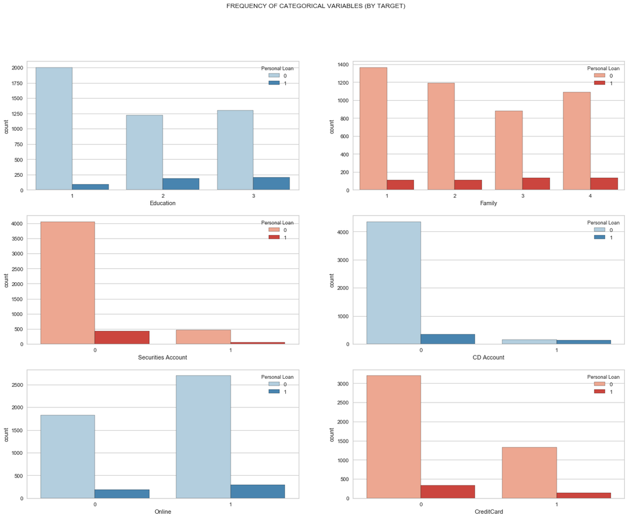

```python
#Creating subset for categorical field visualization
subset = loan[['Education','Personal Loan','Family','Securities Account','CD Account','Online','CreditCard']]

subset.info()



f, plot = plt.subplots(3, 2, figsize=(20, 15), facecolor='white')

f.suptitle('FREQUENCY OF CATEGORICAL VARIABLES (BY TARGET)')

plot1 = sns.countplot(x = "Education",data=subset,hue="Personal Loan",palette="Blues",ax=plot[0,0],edgecolor = 'black')
plot2 = sns.countplot(x = "Family",data=subset,hue="Personal Loan",palette="Reds",ax=plot[0,1],edgecolor = 'black')
plot3 = sns.countplot(x = "Securities Account",data=subset,hue="Personal Loan",palette="Reds",ax=plot[1,0],edgecolor = 'black')
plot4 = sns.countplot(x = "CD Account",data=subset,hue="Personal Loan",palette="Blues",ax=plot[1,1],edgecolor = 'black')
plot5 = sns.countplot(x = "Online",data=subset,hue="Personal Loan",palette="Blues",ax=plot[2,0],edgecolor = 'black')
plot6 = sns.countplot(x = "CreditCard",data=subset,hue="Personal Loan",palette="Reds",ax=plot[2,1],edgecolor = 'black')
```

# Univariate Analysis of the Nmerical variables

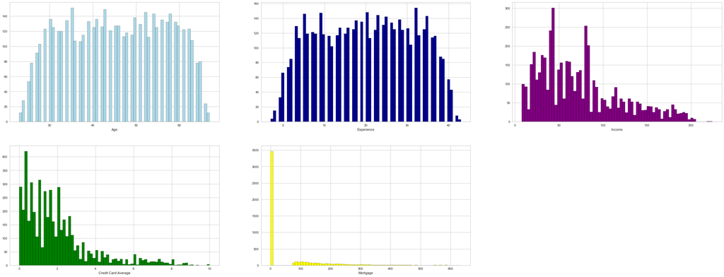

```python
plt.figure(figsize= (40.5,40.5))
plt.subplot(5,3,1)
plt.hist(loan.Age, color='lightblue', edgecolor = 'black',bins=int(np.sqrt(5000)))
plt.xlabel('Age')

plt.subplot(5,3,2)
plt.hist(loan.Experience, color='darkblue', edgecolor = 'black',bins=int(np.sqrt(5000)))
plt.xlabel('Experience')

plt.subplot(5,3,3)
plt.hist(loan.Income, color='purple', edgecolor = 'black',bins=int(np.sqrt(5000)))
plt.xlabel('Income')

plt.subplot(5,3,4)
plt.hist(loan.CCAvg, color='green', edgecolor = 'black',bins=int(np.sqrt(5000)))
plt.xlabel('Credit Card Average')

plt.subplot(5,3,5)
plt.hist(loan.Mortgage, color='yellow', edgecolor = 'black',bins=int(np.sqrt(5000)))
plt.xlabel('Mortgage')

plt.show()
```

- Age and Experience are somewhat normally distributed, where as Income and CC Avg are positive skewed.

```python
loan.head(2)
```

|  | ID | Age | Experience | Income | ZIP Code | Family | CCAvg | Education | Mortgage | Securities Account | CD Account | Online | CreditCard | City | Personal Loan |
| --- | --- | --- | --- | --- | --- | --- | --- | --- | --- | --- | --- | --- | --- | --- | --- |
| 0 | 1 | 25 | 1 | 49 | 91107 | 4 | 1.6 | 1 | 0 | 1 | 0 | 0 | 0 | Pasadena | 0 |
| 1 | 2 | 45 | 19 | 34 | 90089 | 3 | 1.5 | 1 | 0 | 1 | 0 | 0 | 0 | Los Angeles | 0 |

```python
#Calculate baseline proportion - ratio of Yes to No to identify data imbalance
prop_Y = loan['Personal Loan'].value_counts(normalize=True)
print(prop_Y)
```

```
0    0.904
1    0.096
Name: Personal Loan, dtype: float64
```

```python
# Number of people with zero mortgage?

loan['Mortgage'].value_counts()
```

```
0      3462
98       17
103      16
119      16
83       16
       ...
541       1
509       1
505       1
485       1
577       1
Name: Mortgage, Length: 347, dtype: int64
```

```python
#Number of people with zero credit card spending per month?
# Value counts of all categorical columns.

for i in list(loan.columns[loan.dtypes=='category']):
    print(loan[i].value_counts())
    print()
```

```
1    1472
2    1296
4    1222
3    1010
Name: Family, dtype: int64

1    2096
3    1501
2    1403
Name: Education, dtype: int64

0    4478
1     522
Name: Securities Account, dtype: int64

0    4698
1     302
Name: CD Account, dtype: int64

1    2984
0    2016
Name: Online, dtype: int64

0    3530
1    1470
Name: CreditCard, dtype: int64

0    4520
1     480
Name: Personal Loan, dtype: int64
```

# Univariate Analysis of the categorical variables¶

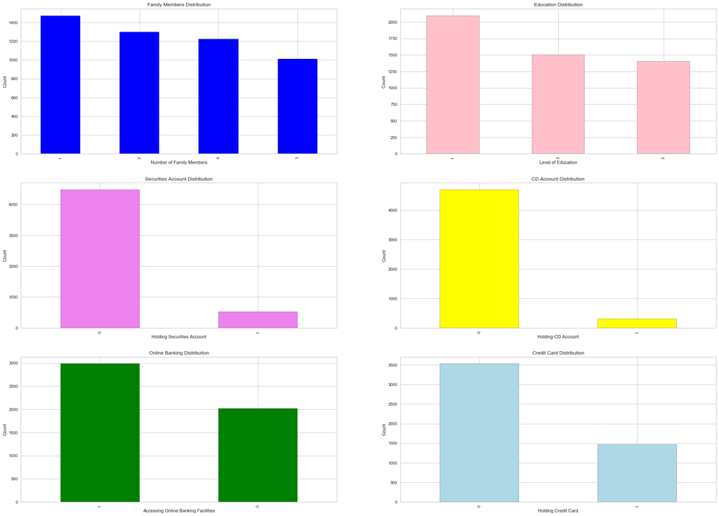

```python
plt.figure(figsize=(30,45))


plt.subplot(6,2,1)
loan['Family'].value_counts().plot(kind="bar", align='center',color = 'blue',edgecolor = 'black')
plt.xlabel("Number of Family Members")
plt.ylabel("Count")
plt.title("Family Members Distribution")


plt.subplot(6,2,2)
loan['Education'].value_counts().plot(kind="bar", align='center',color = 'pink',edgecolor = 'black')
plt.xlabel('Level of Education')
plt.ylabel('Count ')
plt.title('Education Distribution')


plt.subplot(6,2,3)
loan['Securities Account'].value_counts().plot(kind="bar", align='center',color = 'violet',edgecolor = 'black')
plt.xlabel('Holding Securities Account')
plt.ylabel('Count')
plt.title('Securities Account Distribution')


plt.subplot(6,2,4)
loan['CD Account'].value_counts().plot(kind="bar", align='center',color = 'yellow',edgecolor = 'black')
plt.xlabel('Holding CD Account')
plt.ylabel('Count')
plt.title("CD Account Distribution")


plt.subplot(6,2,5)
loan['Online'].value_counts().plot(kind="bar", align='center',color = 'green',edgecolor = 'black')
plt.xlabel('Accessing Online Banking Facilities')
plt.ylabel('Count')
plt.title("Online Banking Distribution")


plt.subplot(6,2,6)
loan['CreditCard'].value_counts().plot(kind="bar", align='center',color = 'lightblue',edgecolor = 'black')
plt.xlabel('Holding Credit Card')
plt.ylabel('Count')
plt.title("Credit Card Distribution")
```

# Dependent Variable Analysis

```python
loan["Personal Loan"].value_counts().to_frame()
```

|  | Personal Loan |
| --- | --- |
| 0 | 4520 |
| 1 | 480 |

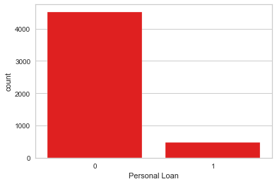

```python
sns.countplot(x='Personal Loan',data=loan,color='red')
plt.show()
```

# Influence of few attributes on 'Personal Loan' - Dependant Variable

```python
#checking balancing of dataset
loan['Personal Loan'].value_counts(normalize=True)
```

```
0    0.904
1    0.096
Name: Personal Loan, dtype: float64
```

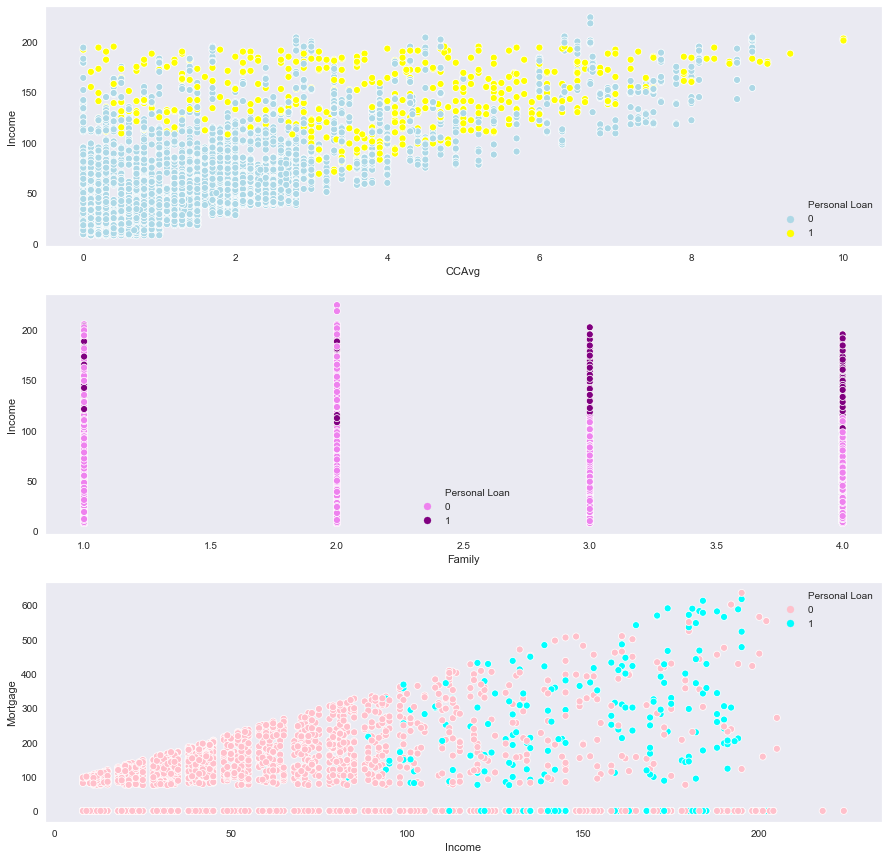

```python
plt.figure(figsize=(15,15))
sns.set_style("dark")

plt.subplot(3,1,1)
sns.scatterplot(x = 'CCAvg', y='Income',data=loan, hue = 'Personal Loan', palette= ['lightblue','yellow'])

plt.subplot(3,1,2)
sns.scatterplot(x = 'Family', y='Income',data=loan, hue = 'Personal Loan', palette= ['violet','purple'])

plt.subplot(3,1,3)
sns.scatterplot(x = 'Income', y='Mortgage',data=loan, hue = 'Personal Loan', palette= ['pink','cyan'])
plt.show()
```

# observation

- The graph show persons who have personal loan have a higher credit card average.
- It is clearly visible that as the members of family increases (say >=3) the necessity of loan is also increasing.
- It is very precise that as the income increases (approx 100K) the mortgage value also increases gradually wiht the necessity of personal loan.

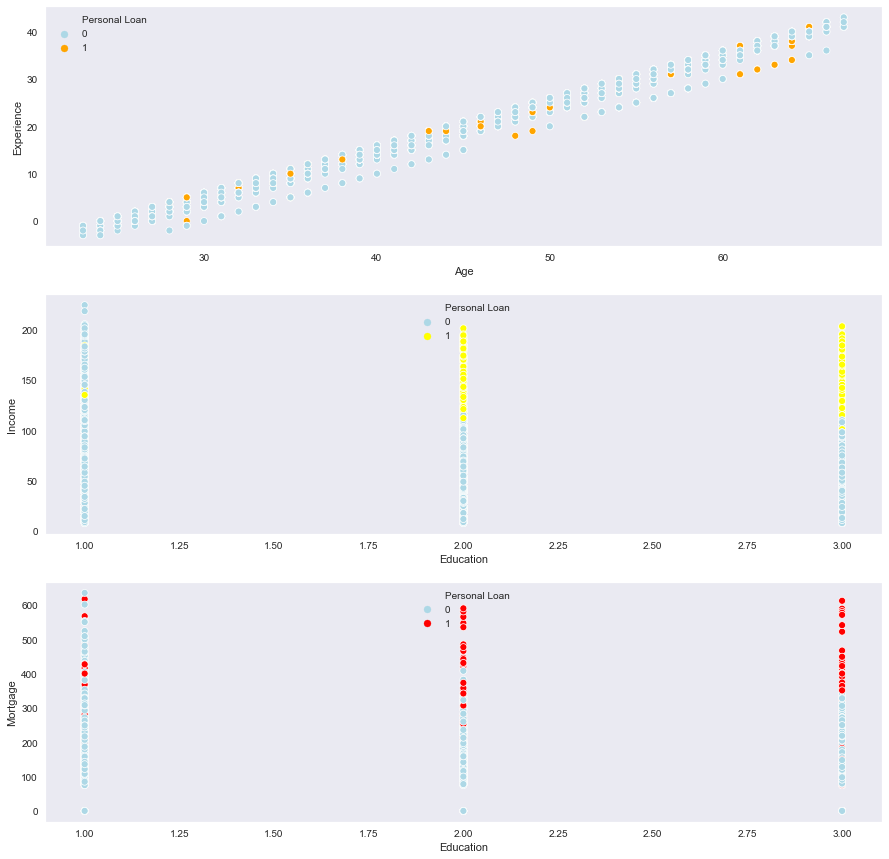

```python
plt.figure(figsize=(15,15))
sns.set_style("dark")

plt.subplot(3,1,1)
sns.scatterplot(x='Age', y='Experience',data=loan, hue = 'Personal Loan', palette= ['lightblue','orange'])

plt.subplot(3,1,2)
sns.scatterplot(x='Education', y='Income',data=loan, hue = 'Personal Loan', palette= ['lightblue','yellow'])

plt.subplot(3,1,3)
sns.scatterplot(x='Education', y='Mortgage',data=loan, hue = 'Personal Loan', palette= ['lightblue','red'])
plt.show()
```

# Observation

- 'Age' has a very strong association with 'Experience' but nothing gets affected with loan attribute.
- It seems that customers with education level is 1 is having more income which is mere equal to the customers who has taken the personal loan.
- Customers with education level 2 & 3 seems to take personal loan as they have high mortgage.

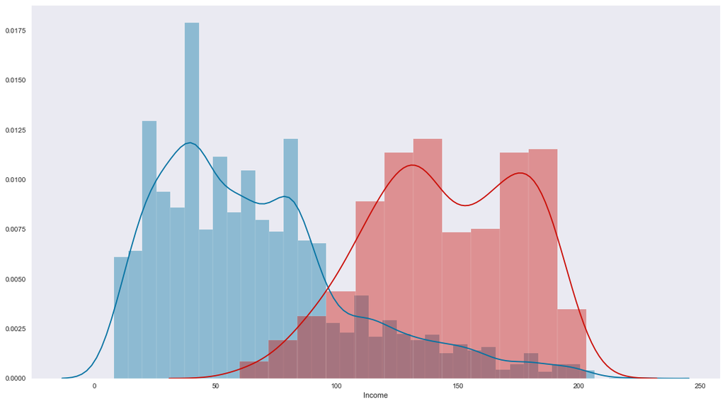

```python
plt.figure(figsize=(18,10))
sns.distplot(loan[loan["Personal Loan"] == 0]['Income'], color = 'b')
sns.distplot(loan[loan["Personal Loan"] == 1]['Income'], color = 'r')
plt.show()
```

- The graph show those who have personal loan also have a higher income.

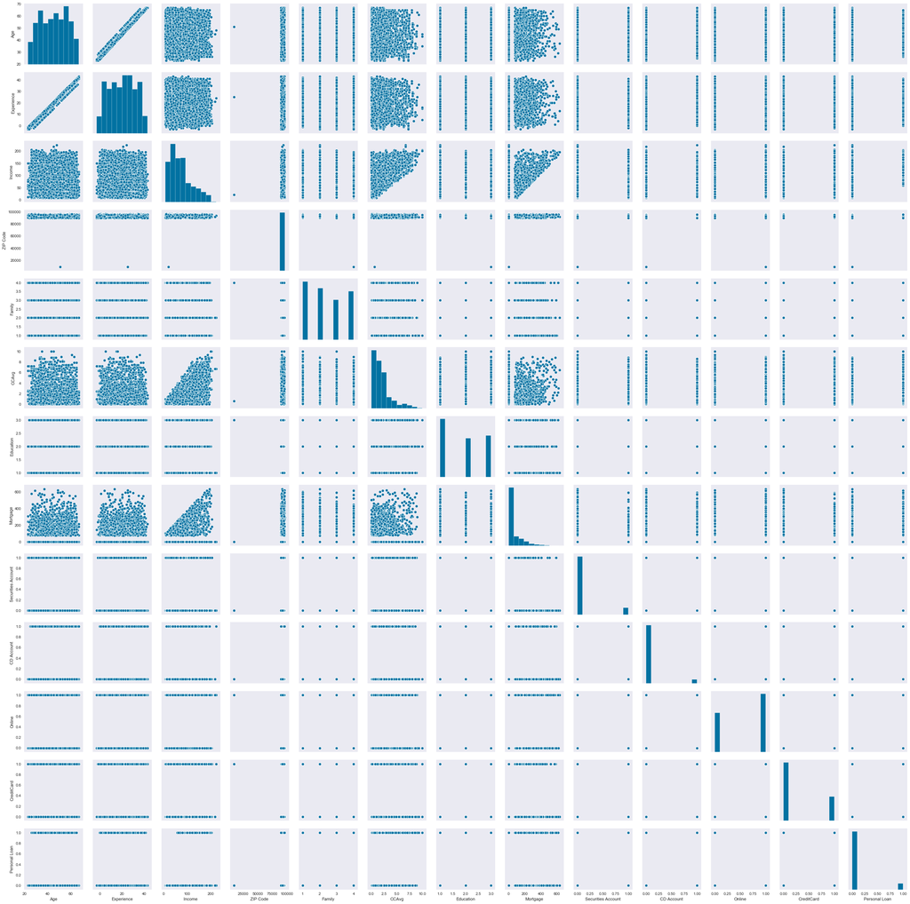

```python
#Pairplot

sns.pairplot(loan.iloc[:,1:])
```

- Age' has an association with 'Experience

```python
# Numerical data field description.

loan.describe().transpose()
```

|  | count | mean | std | min | 25% | 50% | 75% | max |
| --- | --- | --- | --- | --- | --- | --- | --- | --- |
| ID | 5000.0 | 2500.500000 | 1443.520003 | 1.0 | 1250.75 | 2500.5 | 3750.25 | 5000.0 |
| Age | 5000.0 | 45.338400 | 11.463166 | 23.0 | 35.00 | 45.0 | 55.00 | 67.0 |
| Experience | 5000.0 | 20.104600 | 11.467954 | -3.0 | 10.00 | 20.0 | 30.00 | 43.0 |
| Income | 5000.0 | 73.774200 | 46.033729 | 8.0 | 39.00 | 64.0 | 98.00 | 224.0 |
| ZIP Code | 5000.0 | 93152.503000 | 2121.852197 | 9307.0 | 91911.00 | 93437.0 | 94608.00 | 96651.0 |
| CCAvg | 5000.0 | 1.937938 | 1.747659 | 0.0 | 0.70 | 1.5 | 2.50 | 10.0 |
| Mortgage | 5000.0 | 56.498800 | 101.713802 | 0.0 | 0.00 | 0.0 | 101.00 | 635.0 |

# Checking for correlation

```python
loan[['Personal Loan', 'Age', 'Income', 'CCAvg', 'Mortgage']].corr()
```

|  | Age | Income | CCAvg | Mortgage |
| --- | --- | --- | --- | --- |
| Age | 1.000000 | -0.055269 | -0.052012 | -0.012539 |
| Income | -0.055269 | 1.000000 | 0.645984 | 0.206806 |
| CCAvg | -0.052012 | 0.645984 | 1.000000 | 0.109905 |
| Mortgage | -0.012539 | 0.206806 | 0.109905 | 1.000000 |

```
(0, 4)
```

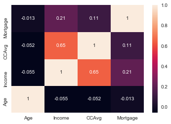

```python
sns.heatmap(loan[['Personal Loan', 'Age', 'Income', 'CCAvg', 'Mortgage']].corr(), annot = True)
plt.ylim(0,4)
```

```python
loan.groupby(['Personal Loan']).count()
```

| Personal Loan | ID | Age | Experience | Income | ZIP Code | Family | CCAvg | Education | Mortgage | Securities Account | CD Account | Online | CreditCard | City |
| --- | --- | --- | --- | --- | --- | --- | --- | --- | --- | --- | --- | --- | --- | --- |
| 0 | 4520 | 4520 | 4520 | 4520 | 4520 | 4520 | 4520 | 4520 | 4520 | 4520 | 4520 | 4520 | 4520 | 4520 |
| 1 | 480 | 480 | 480 | 480 | 480 | 480 | 480 | 480 | 480 | 480 | 480 | 480 | 480 | 480 |

# ------------------------------------------ Logistic Regression ----------------------------------------

### Model building using Logistic Regression from Sklearn

We will use the sklearn library to build the model and make predictions

```python
# Define X & Y variables

X = loan.drop(['ID'],axis=1).drop(labels= "Personal Loan" , axis = 1)
Y = loan['Personal Loan'].values


#Convert Categorical Variables to dummy variables

X = pd.get_dummies(X, drop_first=True)
```

```python
X
```

|  | Age | Experience | Income | ZIP Code | CCAvg | Mortgage | Family_2 | Family_3 | Family_4 | Education_2 | ... | City_Vista | City_Walnut Creek | City_Weed | City_West Covina | City_West Sacramento | City_Westlake Village | City_Whittier | City_Woodland Hills | City_Yorba Linda | City_Yucaipa |
| --- | --- | --- | --- | --- | --- | --- | --- | --- | --- | --- | --- | --- | --- | --- | --- | --- | --- | --- | --- | --- | --- |
| 0 | 25 | 1 | 49 | 91107 | 1.6 | 0 | 0 | 0 | 1 | 0 | ... | 0 | 0 | 0 | 0 | 0 | 0 | 0 | 0 | 0 | 0 |
| 1 | 45 | 19 | 34 | 90089 | 1.5 | 0 | 0 | 1 | 0 | 0 | ... | 0 | 0 | 0 | 0 | 0 | 0 | 0 | 0 | 0 | 0 |
| 2 | 39 | 15 | 11 | 94720 | 1.0 | 0 | 0 | 0 | 0 | 0 | ... | 0 | 0 | 0 | 0 | 0 | 0 | 0 | 0 | 0 | 0 |
| 3 | 35 | 9 | 100 | 94112 | 2.7 | 0 | 0 | 0 | 0 | 1 | ... | 0 | 0 | 0 | 0 | 0 | 0 | 0 | 0 | 0 | 0 |
| 4 | 35 | 8 | 45 | 91330 | 1.0 | 0 | 0 | 0 | 1 | 1 | ... | 0 | 0 | 0 | 0 | 0 | 0 | 0 | 0 | 0 | 0 |
| ... | ... | ... | ... | ... | ... | ... | ... | ... | ... | ... | ... | ... | ... | ... | ... | ... | ... | ... | ... | ... | ... |
| 4995 | 29 | 3 | 40 | 92697 | 1.9 | 0 | 0 | 0 | 0 | 0 | ... | 0 | 0 | 0 | 0 | 0 | 0 | 0 | 0 | 0 | 0 |
| 4996 | 30 | 4 | 15 | 92037 | 0.4 | 85 | 0 | 0 | 1 | 0 | ... | 0 | 0 | 0 | 0 | 0 | 0 | 0 | 0 | 0 | 0 |
| 4997 | 63 | 39 | 24 | 93023 | 0.3 | 0 | 1 | 0 | 0 | 0 | ... | 0 | 0 | 0 | 0 | 0 | 0 | 0 | 0 | 0 | 0 |
| 4998 | 65 | 40 | 49 | 90034 | 0.5 | 0 | 0 | 1 | 0 | 1 | ... | 0 | 0 | 0 | 0 | 0 | 0 | 0 | 0 | 0 | 0 |
| 4999 | 28 | 4 | 83 | 92612 | 0.8 | 0 | 0 | 1 | 0 | 0 | ... | 0 | 0 | 0 | 0 | 0 | 0 | 0 | 0 | 0 | 0 |

5000 rows × 261 columns

```python
Y
```

```
[0, 0, 0, 0, 0, ..., 0, 0, 0, 0, 0]
Length: 5000
Categories (2, int64): [0, 1]
```

```python
##Split into training and test set

X_train,X_test,y_train,y_test = train_test_split(X,Y, test_size = 0.30, random_state=42 )
```

```python
#model1

logreg =LogisticRegression()
logreg.fit(X_train,y_train)
```

```
LogisticRegression(C=1.0, class_weight=None, dual=False, fit_intercept=True,
                   intercept_scaling=1, l1_ratio=None, max_iter=100,
                   multi_class='auto', n_jobs=None, penalty='l2',
                   random_state=None, solver='lbfgs', tol=0.0001, verbose=0,
                   warm_start=False)
```

```python
#saving predictions
y_predict = logreg.predict(X_test)
```

```
training_accuracy: 0.9105714285714286
testing_accuracy: 0.9013333333333333
```

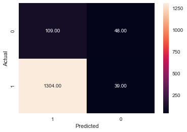

```
[[1304   39]
 [ 109   48]]

recall_score: 0.3057324840764331
precision_score: 0.5517241379310345
f1_score: 0.39344262295081966
roc_auc_score: 0.6383465100948063
```

```python
confusion_matrix(y_test,y_predict)
print()

training_accuracy = logreg.score(X_train,y_train)
print('training_accuracy:',training_accuracy)

testing_accuracy = logreg.score(X_test,y_test)
print('testing_accuracy:',testing_accuracy)

cm =confusion_matrix(y_test,y_predict)
cm =confusion_matrix(y_test,y_predict)
sns.heatmap(cm,annot=True,fmt='.2f',xticklabels = [1,0],yticklabels=[1,0])
plt.ylabel('Actual')
plt.xlabel('Predicted')
plt.ylim(0,2)
plt.show()
print(cm)
print()
print("recall_score:",recall_score(y_test,y_predict))
print('precision_score:',precision_score(y_test,y_predict))
print('f1_score:',f1_score(y_test,y_predict))
print('roc_auc_score:',roc_auc_score(y_test,y_predict))
```

- Accuracy is good but other classification scores are poor.

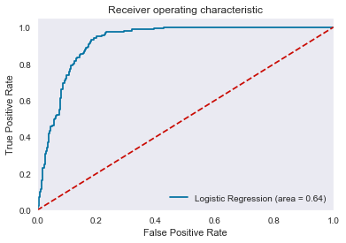

```python
#AUC ROC curve

logit_roc_auc = roc_auc_score(y_test, logreg.predict(X_test))
fpr, tpr, thresholds = roc_curve(y_test, logreg.predict_proba(X_test)[:,1])
plt.figure()
plt.plot(fpr, tpr, label='Logistic Regression (area = %0.2f)' % logit_roc_auc)
plt.plot([0, 1], [0, 1],'r--')
plt.xlim([0.0, 1.0])
plt.ylim([0.0, 1.05])
plt.xlabel('False Positive Rate')
plt.ylabel('True Positive Rate')
plt.title('Receiver operating characteristic')
plt.legend(loc="lower right")
plt.savefig('Log_ROC')
plt.show()
```

```python
# Import MinMaxScaler
```

```python
#from sklearn.preprocessing import MinMaxScaler
```

```python
# Instantiate MinMaxScaler and use it to rescale X_train and X_test
#scaler = MinMaxScaler(feature_range=(0,1))
#rescaledX_train = scaler.fit(X)
#rescaledX_test = scaler.fit(X)
```

**Checking Parameters of Logistic Regression**

```python
# Checking Parameters of logistic regression
logreg.get_params()

#If we dont specify the parameters in the model it takes default value
```

```
{'C': 1.0,
 'class_weight': None,
 'dual': False,
 'fit_intercept': True,
 'intercept_scaling': 1,
 'l1_ratio': None,
 'max_iter': 100,
 'multi_class': 'auto',
 'n_jobs': None,
 'penalty': 'l2',
 'random_state': None,
 'solver': 'lbfgs',
 'tol': 0.0001,
 'verbose': 0,
 'warm_start': False}
```

### Tuning Hyper-Parameters to improve classification scores

```python
# Running a loop to check different values of 'solver'
# solver can only be used with l2, only 'liblinear' works with both 'l1' and 'l2'

train_score=[]
test_score=[]
solver = ['newton-cg','lbfgs','liblinear','sag','saga']
for i in solver:
    model = LogisticRegression(random_state=42,penalty='l2', C = 0.75,solver=i)  # changing values of solver
    model.fit(X_train, y_train)
    y_predict = model.predict(X_test)
    train_score.append(round(model.score(X_train, y_train),3))
    test_score.append(round(model.score(X_test, y_test),3))

print(solver)
print()
print(train_score)
print()
print(test_score)
```

```
['newton-cg', 'lbfgs', 'liblinear', 'sag', 'saga']

[0.959, 0.911, 0.911, 0.908, 0.908]

[0.963, 0.901, 0.901, 0.895, 0.895]
```

```python
#model2

model = LogisticRegression(random_state=42,penalty='l2',solver='lbfgs',class_weight='balanced')
model =logreg.fit(X_train,y_train)

y_predict = model.predict(X_test)

cm = confusion_matrix(y_test,y_predict)
print(cm)
print("Trainig accuracy",model.score(X_train,y_train))
print()
print("Testing accuracy",model.score(X_test, y_test))
print()
print(classification_report(y_test,y_predict))
```

```
[[1304   39]
 [ 109   48]]
Trainig accuracy 0.9105714285714286

Testing accuracy 0.9013333333333333

              precision    recall  f1-score   support

           0       0.92      0.97      0.95      1343
           1       0.55      0.31      0.39       157

    accuracy                           0.90      1500
   macro avg       0.74      0.64      0.67      1500
weighted avg       0.88      0.90      0.89      1500
```

```python
# Running a loop to check different values of 'C'

train_score = []
test_score = []
C = [0.1,0.2,0.3,0.4,0.5,0.6,0.7,0.8,0.9,1]

for i in C:
    model =LogisticRegression(random_state=42,penalty='l2',solver='lbfgs',class_weight='balanced',C=i)
    model.fit(X_train, y_train)
    y_predict = model.predict(X_test)
    train_score.append(round(model.score(X_train,y_train),3))
    test_score.append(round(model.score(X_test,y_test),3))
print(C)
print()
print(train_score)
print()
print(test_score)
```

```
[0.1, 0.2, 0.3, 0.4, 0.5, 0.6, 0.7, 0.8, 0.9, 1]

[0.849, 0.849, 0.849, 0.849, 0.849, 0.849, 0.849, 0.849, 0.849, 0.849]

[0.847, 0.847, 0.847, 0.847, 0.847, 0.847, 0.847, 0.847, 0.847, 0.847]
```

```python
#model3

model_1 = LogisticRegression(random_state=42,penalty='l2',solver='lbfgs',class_weight='balanced',C=0.3)
model_1 = logreg.fit(X_train,y_train)

y_predict = model_1.predict(X_test)

print(cm)
print("Trainig accuracy",model_1.score(X_train,y_train))
print()
print("Testing accuracy",model_1.score(X_test, y_test))
print()
print(classification_report(y_test,y_predict))
```

```
[[1304   39]
 [ 109   48]]
Trainig accuracy 0.9105714285714286

Testing accuracy 0.9013333333333333

              precision    recall  f1-score   support

           0       0.92      0.97      0.95      1343
           1       0.55      0.31      0.39       157

    accuracy                           0.90      1500
   macro avg       0.74      0.64      0.67      1500
weighted avg       0.88      0.90      0.89      1500
```

```python
# Running a loop to check different values of 'intercept_scaling'

train_score = []
test_score = []
intercept_scaling = [0.1,0.2,0.3,0.4,0.5,0.6,0.7,0.8,0.9,1]

for i in intercept_scaling:
    model_1 =LogisticRegression(random_state=42,penalty='l2',solver='lbfgs',class_weight='balanced',C=0.3,intercept_scaling=i)
    model_1.fit(X_train, y_train)
    y_predict = model_1.predict(X_test)
    train_score.append(round(model_1.score(X_train,y_train),3))
    test_score.append(round(model_1.score(X_test,y_test),3))
print(C)
print()
print(train_score)
print()
print(test_score)
```

```
[0.1, 0.2, 0.3, 0.4, 0.5, 0.6, 0.7, 0.8, 0.9, 1]

[0.849, 0.849, 0.849, 0.849, 0.849, 0.849, 0.849, 0.849, 0.849, 0.849]

[0.847, 0.847, 0.847, 0.847, 0.847, 0.847, 0.847, 0.847, 0.847, 0.847]
```

```python
#model4

model_2 = LogisticRegression(random_state=42,penalty='ecastinet',solver='sag',C=1,class_weight='balanced',intercept_scaling=0.3)
model_2 = logreg.fit(X_train,y_train)

y_predict = model_2.predict(X_test)

cm =confusion_matrix(y_test,y_predict)
print(cm)
print("Trainig accuracy",model_2.score(X_train,y_train))
print()
print("Testing accuracy",model_2.score(X_test, y_test))
print()
print(classification_report(y_test,y_predict))
```

```
[[1304   39]
 [ 109   48]]
Trainig accuracy 0.9105714285714286

Testing accuracy 0.9013333333333333

              precision    recall  f1-score   support

           0       0.92      0.97      0.95      1343
           1       0.55      0.31      0.39       157

    accuracy                           0.90      1500
   macro avg       0.74      0.64      0.67      1500
weighted avg       0.88      0.90      0.89      1500
```

### Using different Data Resampling technique

##### UnderSampling Data

```python
rus = RandomUnderSampler(random_state=42)
X_under, y_under = rus.fit_resample(X, Y)
print('Resampled dataset shape %s' % Counter(y_under))
print('Original dataset shape %s' % Counter(Y))
```

```
Resampled dataset shape Counter({0: 480, 1: 480})
Original dataset shape Counter({0: 4520, 1: 480})
```

##### OverSampling Data

```python
rus = RandomOverSampler(random_state=42)
X_over, y_over = rus.fit_resample(X, Y)
print('Resampled dataset shape %s' % Counter(y_over))
print('Original dataset shape %s' % Counter(Y))
```

```
Resampled dataset shape Counter({0: 4520, 1: 4520})
Original dataset shape Counter({0: 4520, 1: 480})
```

##### SMOTE Data

```python
rus = SMOTE(random_state=42)
X_smote, y_smote = rus.fit_resample(X, Y)
print('Resampled dataset shape %s' % Counter(y_smote))
print('Original dataset shape %s' % Counter(Y))
```

```
Resampled dataset shape Counter({0: 4520, 1: 4520})
Original dataset shape Counter({0: 4520, 1: 480})
```

# --------------------Applying RandomUnder Sampling------------------------------------

```python
from collections import Counter
from imblearn.under_sampling import RandomUnderSampler
from imblearn.over_sampling import RandomOverSampler
```

```python
##Split into training and test set

X_train,X_test,y_train,y_test = train_test_split(X_under,y_under, test_size = 0.30, random_state=42 )

logreg =LogisticRegression()
logreg.fit(X_train,y_train)
```

```
LogisticRegression(C=1.0, class_weight=None, dual=False, fit_intercept=True,
                   intercept_scaling=1, l1_ratio=None, max_iter=100,
                   multi_class='auto', n_jobs=None, penalty='l2',
                   random_state=None, solver='lbfgs', tol=0.0001, verbose=0,
                   warm_start=False)
```

```
training_accuracy: 0.8571428571428571
testing_accuracy: 0.8611111111111112
```

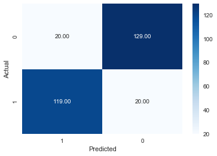

```
[[119  20]
 [ 20 129]]

roc_auc_score: 0.860943459997103

              precision    recall  f1-score   support

           0       0.86      0.86      0.86       139
           1       0.87      0.87      0.87       149

    accuracy                           0.86       288
   macro avg       0.86      0.86      0.86       288
weighted avg       0.86      0.86      0.86       288
```

```python
y_predict = logreg.predict(X_test)

confusion_matrix(y_test,y_predict)
print()

training_accuracy = logreg.score(X_train,y_train)
print('training_accuracy:',training_accuracy)

testing_accuracy = logreg.score(X_test,y_test)
print('testing_accuracy:',testing_accuracy)

cm =confusion_matrix(y_test,y_predict)
cm =confusion_matrix(y_test,y_predict)
sns.heatmap(cm,annot=True,fmt='.2f',xticklabels = [1,0],yticklabels=[1,0],cmap='Blues')
plt.ylabel('Actual')
plt.xlabel('Predicted')
plt.ylim(0,2)
plt.show()
print(cm)
print()
print('roc_auc_score:',roc_auc_score(y_test,y_predict))
print()
print(classification_report(y_test,y_predict))
```

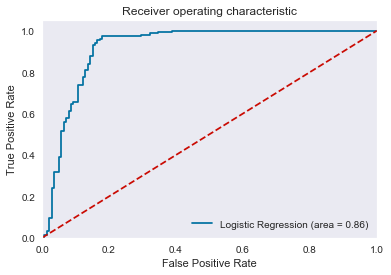

```python
#AUC ROC curve

logit_roc_auc = roc_auc_score(y_test, logreg.predict(X_test))
fpr, tpr, thresholds = roc_curve(y_test, logreg.predict_proba(X_test)[:,1])
plt.figure()
plt.plot(fpr, tpr, label='Logistic Regression (area = %0.2f)' % logit_roc_auc)
plt.plot([0, 1], [0, 1],'r--')
plt.xlim([0.0, 1.0])
plt.ylim([0.0, 1.05])
plt.xlabel('False Positive Rate')
plt.ylabel('True Positive Rate')
plt.title('Receiver operating characteristic')
plt.legend(loc="lower right")
plt.savefig('Log_ROC')
plt.show()
```

# --------------------Applying Random Over Sampling------------------------------------

```python
##Split into training and test set

X_train,X_test,y_train,y_test = train_test_split(X_over,y_over, test_size = 0.30, random_state=42)


logreg =LogisticRegression()
logreg.fit(X_train,y_train)
```

```
LogisticRegression(C=1.0, class_weight=None, dual=False, fit_intercept=True,
                   intercept_scaling=1, l1_ratio=None, max_iter=100,
                   multi_class='auto', n_jobs=None, penalty='l2',
                   random_state=None, solver='lbfgs', tol=0.0001, verbose=0,
                   warm_start=False)
```

```
training_accuracy: 0.8587231352718079
testing_accuracy: 0.8672566371681416
```

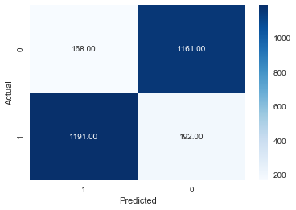

```
[[1191  192]
 [ 168 1161]]

roc_auc_score: 0.8673802656899566

              precision    recall  f1-score   support

           0       0.88      0.86      0.87      1383
           1       0.86      0.87      0.87      1329

    accuracy                           0.87      2712
   macro avg       0.87      0.87      0.87      2712
weighted avg       0.87      0.87      0.87      2712
```

```python
y_predict = logreg.predict(X_test)

confusion_matrix(y_test,y_predict)
print()

training_accuracy = logreg.score(X_train,y_train)
print('training_accuracy:',training_accuracy)

testing_accuracy = logreg.score(X_test,y_test)
print('testing_accuracy:',testing_accuracy)

cm =confusion_matrix(y_test,y_predict)
cm =confusion_matrix(y_test,y_predict)
sns.heatmap(cm,annot=True,fmt='.2f',xticklabels = [1,0],yticklabels=[1,0],cmap='Blues')
plt.ylabel('Actual')
plt.xlabel('Predicted')
plt.ylim(0,2)
plt.show()
print(cm)
print()
print('roc_auc_score:',roc_auc_score(y_test,y_predict))
print()
print(classification_report(y_test,y_predict))
```

# --------------------Applying SMOTE------------------------------------

```python
##Split into training and test set

X_train,X_test,y_train,y_test = train_test_split(X_smote,y_smote, test_size = 0.30, random_state=42 )

logreg =LogisticRegression(random_state=42, solver="liblinear",penalty='l2')
logreg.fit(X_train,y_train)
```

```
LogisticRegression(C=1.0, class_weight=None, dual=False, fit_intercept=True,
                   intercept_scaling=1, l1_ratio=None, max_iter=100,
                   multi_class='auto', n_jobs=None, penalty='l2',
                   random_state=42, solver='liblinear', tol=0.0001, verbose=0,
                   warm_start=False)
```

```
training_accuracy: 0.911504424778761
testing_accuracy: 0.9100294985250738
```

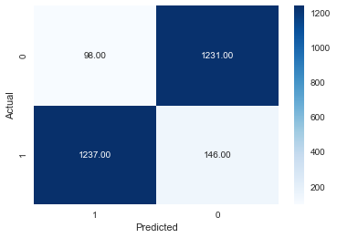

```
[[1237  146]
 [  98 1231]]

roc_auc_score: 0.9103463697363503

              precision    recall  f1-score   support

           0       0.93      0.89      0.91      1383
           1       0.89      0.93      0.91      1329

    accuracy                           0.91      2712
   macro avg       0.91      0.91      0.91      2712
weighted avg       0.91      0.91      0.91      2712
```

```python
y_predict = logreg.predict(X_test)

confusion_matrix(y_test,y_predict)
print()

training_accuracy = logreg.score(X_train,y_train)
print('training_accuracy:',training_accuracy)

testing_accuracy = logreg.score(X_test,y_test)
print('testing_accuracy:',testing_accuracy)

cm =confusion_matrix(y_test,y_predict)
cm =confusion_matrix(y_test,y_predict)
sns.heatmap(cm,annot=True,fmt='.2f',xticklabels = [1,0],yticklabels=[1,0],cmap='Blues')
plt.ylabel('Actual')
plt.xlabel('Predicted')
plt.ylim(0,2)
plt.show()
print(cm)
print()

print('roc_auc_score:',roc_auc_score(y_test,y_predict))
print()
print(classification_report(y_test,y_predict))
```

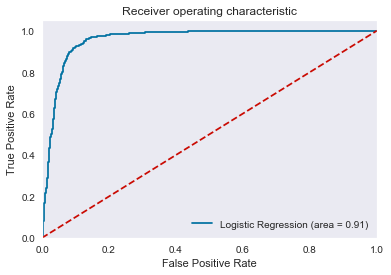

```python
#AUC ROC curve

logit_roc_auc = roc_auc_score(y_test, logreg.predict(X_test))
fpr, tpr, thresholds = roc_curve(y_test, logreg.predict_proba(X_test)[:,1])
plt.figure()
plt.plot(fpr, tpr, label='Logistic Regression (area = %0.2f)' % logit_roc_auc)
plt.plot([0, 1], [0, 1],'r--')
plt.xlim([0.0, 1.0])
plt.ylim([0.0, 1.05])
plt.xlabel('False Positive Rate')
plt.ylabel('True Positive Rate')
plt.title('Receiver operating characteristic')
plt.legend(loc="lower right")
plt.savefig('Log_ROC')
plt.show()
```

```python
# Keeping solver "newton-cg"
```

```python
##Split into training and test set

X_train,X_test,y_train,y_test = train_test_split(X_smote,y_smote, test_size = 0.30, random_state=42 )

logreg =LogisticRegression(random_state=42, solver="newton-cg",penalty='l2')
logreg.fit(X_train,y_train)
```

```
LogisticRegression(C=1.0, class_weight=None, dual=False, fit_intercept=True,
                   intercept_scaling=1, l1_ratio=None, max_iter=100,
                   multi_class='auto', n_jobs=None, penalty='l2',
                   random_state=42, solver='newton-cg', tol=0.0001, verbose=0,
                   warm_start=False)
```

```
training_accuracy: 0.9262010113780025
testing_accuracy: 0.9203539823008849
```

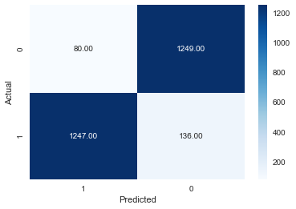

```
[[1247  136]
 [  80 1249]]

roc_auc_score: 0.9207337077606342

              precision    recall  f1-score   support

           0       0.94      0.90      0.92      1383
           1       0.90      0.94      0.92      1329

    accuracy                           0.92      2712
   macro avg       0.92      0.92      0.92      2712
weighted avg       0.92      0.92      0.92      2712
```

```python
y_predict = logreg.predict(X_test)

confusion_matrix(y_test,y_predict)
print()

training_accuracy = logreg.score(X_train,y_train)
print('training_accuracy:',training_accuracy)

testing_accuracy = logreg.score(X_test,y_test)
print('testing_accuracy:',testing_accuracy)

cm =confusion_matrix(y_test,y_predict)
cm =confusion_matrix(y_test,y_predict)
sns.heatmap(cm,annot=True,fmt='.2f',xticklabels = [1,0],yticklabels=[1,0],cmap='Blues')
plt.ylabel('Actual')
plt.xlabel('Predicted')
plt.ylim(0,2)
plt.show()
print(cm)
print()

print('roc_auc_score:',roc_auc_score(y_test,y_predict))
print()
print(classification_report(y_test,y_predict))
```

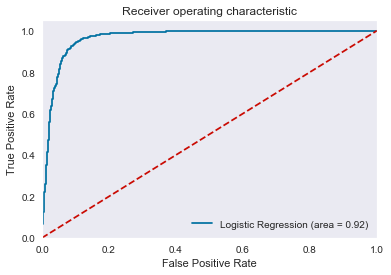

```python
#AUC ROC curve

logit_roc_auc = roc_auc_score(y_test, logreg.predict(X_test))
fpr, tpr, thresholds = roc_curve(y_test, logreg.predict_proba(X_test)[:,1])
plt.figure()
plt.plot(fpr, tpr, label='Logistic Regression (area = %0.2f)' % logit_roc_auc)
plt.plot([0, 1], [0, 1],'r--')
plt.xlim([0.0, 1.0])
plt.ylim([0.0, 1.05])
plt.xlabel('False Positive Rate')
plt.ylabel('True Positive Rate')
plt.title('Receiver operating characteristic')
plt.legend(loc="lower right")
plt.savefig('Log_ROC')
plt.show()
```

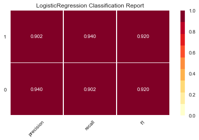

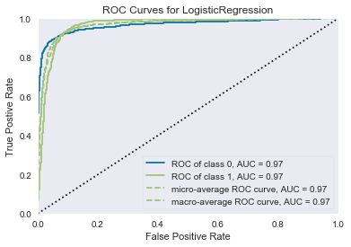

```python
# Additional

from yellowbrick.classifier import ClassificationReport, ROCAUC
# Visualize model performance with yellowbrick library
viz = ClassificationReport(logreg)
viz.fit(X_train, y_train)
viz.score(X_test, y_test)
viz.show()

roc = ROCAUC(logreg)
roc.fit(X_train, y_train)
roc.score(X_test, y_test)
roc.show()
plt.show()
```

```python
##Split into training and test set

X_train,X_test,y_train,y_test = train_test_split(X_smote,y_smote, test_size = 0.30, random_state=42 )

logreg =LogisticRegression(random_state=42, solver="newton-cg",penalty='l2',C=10)
logreg.fit(X_train,y_train)
```

```
LogisticRegression(C=10, class_weight=None, dual=False, fit_intercept=True,
                   intercept_scaling=1, l1_ratio=None, max_iter=100,
                   multi_class='auto', n_jobs=None, penalty='l2',
                   random_state=42, solver='newton-cg', tol=0.0001, verbose=0,
                   warm_start=False)
```

```
training_accuracy: 0.9443742098609356
testing_accuracy: 0.9314159292035398
```

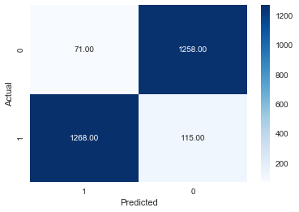

```
[[1268  115]
 [  71 1258]]

roc_auc_score: 0.9317119031646779

              precision    recall  f1-score   support

           0       0.95      0.92      0.93      1383
           1       0.92      0.95      0.93      1329

    accuracy                           0.93      2712
   macro avg       0.93      0.93      0.93      2712
weighted avg       0.93      0.93      0.93      2712
```

```python
y_predict = logreg.predict(X_test)

confusion_matrix(y_test,y_predict)
print()

training_accuracy = logreg.score(X_train,y_train)
print('training_accuracy:',training_accuracy)

testing_accuracy = logreg.score(X_test,y_test)
print('testing_accuracy:',testing_accuracy)

cm =confusion_matrix(y_test,y_predict)
cm =confusion_matrix(y_test,y_predict)
sns.heatmap(cm,annot=True,fmt='.2f',xticklabels = [1,0],yticklabels=[1,0],cmap='Blues')
plt.ylabel('Actual')
plt.xlabel('Predicted')
plt.ylim(0,2)
plt.show()
print(cm)
print()

print('roc_auc_score:',roc_auc_score(y_test,y_predict))
print()
print(classification_report(y_test,y_predict))
```

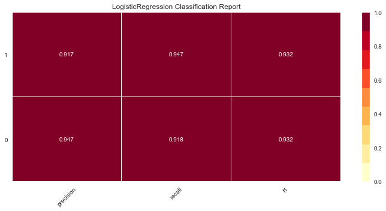

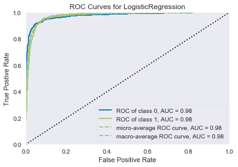

```python
# Additional
plt.figure(figsize=(10,5))
from yellowbrick.classifier import ClassificationReport, ROCAUC
# Visualize model performance with yellowbrick library
viz = ClassificationReport(logreg)
viz.fit(X_train, y_train)
viz.score(X_test, y_test)
viz.show()

roc = ROCAUC(logreg)
roc.fit(X_train, y_train)
roc.score(X_test, y_test)
roc.show()
plt.show()
```

- Best Classificaton score so far using smote oversampling technique in logistic regression algorithm.
- In the above model i have tunned 3 hyperparameters; penaality, solver and C.
- In this model i am getting the best recall for class 1.

### Let's try NearMiss technique to balanced our imbalanced data.

# --------------------Applying NearMiss------------------------------------

```python
print('Original dataset shape %s' % Counter(Y))

nr = NearMiss()
X_res, y_res = nr.fit_resample(X,Y)

print('Resampled dataset shape %s' % Counter(y_res))

##Split into training and test set

X_train,X_test,y_train,y_test = train_test_split(X_res,y_res, test_size = 0.30, random_state=42)

logreg =LogisticRegression()
logreg.fit(X_train,y_train)
```

```
Original dataset shape Counter({0: 4520, 1: 480})
Resampled dataset shape Counter({0: 480, 1: 480})
```

```
LogisticRegression(C=1.0, class_weight=None, dual=False, fit_intercept=True,
                   intercept_scaling=1, l1_ratio=None, max_iter=100,
                   multi_class='auto', n_jobs=None, penalty='l2',
                   random_state=None, solver='lbfgs', tol=0.0001, verbose=0,
                   warm_start=False)
```

```
training_accuracy: 0.7232142857142857
testing_accuracy: 0.7326388888888888
```

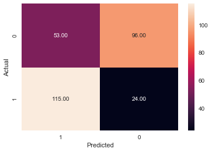

```
[[115  24]
 [ 53  96]]

roc_auc_score: 0.7358167157549128

              precision    recall  f1-score   support

           0       0.68      0.83      0.75       139
           1       0.80      0.64      0.71       149

    accuracy                           0.73       288
   macro avg       0.74      0.74      0.73       288
weighted avg       0.74      0.73      0.73       288
```

```python
y_predict = logreg.predict(X_test)

confusion_matrix(y_test,y_predict)
print()

training_accuracy = logreg.score(X_train,y_train)
print('training_accuracy:',training_accuracy)

testing_accuracy = logreg.score(X_test,y_test)
print('testing_accuracy:',testing_accuracy)

cm =confusion_matrix(y_test,y_predict)
cm =confusion_matrix(y_test,y_predict)
sns.heatmap(cm,annot=True,fmt='.2f',xticklabels = [1,0],yticklabels=[1,0])
plt.ylabel('Actual')
plt.xlabel('Predicted')
plt.ylim(0,2)
plt.show()
print(cm)
print()
print('roc_auc_score:',roc_auc_score(y_test,y_predict))
print()
print(classification_report(y_test,y_predict))
```

- Not a satisfactory result.

[figure not shown]

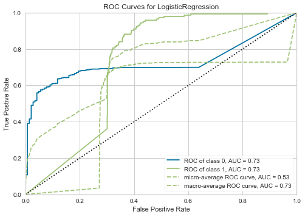

```python
# Additional

from yellowbrick.classifier import ClassificationReport, ROCAUC
# Visualize model performance with yellowbrick library
viz = ClassificationReport(logreg)
viz.fit(X_train, y_train)
viz.score(X_test, y_test)
viz.show()

roc = ROCAUC(logreg)
roc.fit(X_train, y_train)
roc.score(X_test, y_test)
roc.show()
plt.show()
```

### Let's try with another avilable algorithms.

### ------------------------------------------ Naive Bayes Model ----------------------------------------------

```python
#model5
smt = SMOTE()
X_train, y_train = smt.fit_resample(X_train, y_train)

model_NB = GaussianNB()
model_NB.fit(X_train, y_train)
y_pred_NB = model_NB.predict(X_test)


cnf_matrix_NB = confusion_matrix(y_test, y_pred_NB)
print(cnf_matrix_NB)
print("Trainig accuracy",model_NB.score(X_train,y_train))
print()
print("Testing accuracy",model_NB.score(X_test, y_test))
print()

print(classification_report(y_test,y_pred_NB))
print()
print('roc_auc_score:',roc_auc_score(y_test,y_pred_NB))
```

[output not shown]

- Naive Bayes giving good recall but precision and accuracy is comparatively low).**

### ----------------------------------------- KNN Nearest Neighbours ------------------------------------

```python
#model6
smt = SMOTE()
X_train, y_train = smt.fit_resample(X_train, y_train)

knn = KNeighborsClassifier()
knn
knn.fit(X_train,y_train)
y_pred_KNN=knn.predict(X_test)

cnf_matrix_KNN = confusion_matrix(y_test, y_pred_KNN)
print(cnf_matrix_KNN)
print("Trainig accuracy",knn.score(X_train,y_train))
print()
print("Testing accuracy",knn.score(X_test, y_test))
print()
print(classification_report(y_test,y_pred_KNN))
print()
print('roc_auc_score:',roc_auc_score(y_test,y_pred_KNN))
```

[output not shown]

### Undersampled Data

```python
rus = RandomUnderSampler(random_state=42)
X_under, y_under = rus.fit_resample(X, Y)
print('Resampled dataset shape %s' % Counter(y_under))
```

```
Resampled dataset shape Counter({0: 480, 1: 480})
```

### Oversampled Data

```python
rus = RandomOverSampler(random_state=42)
X_over, y_over = rus.fit_resample(X, Y)
print('Resampled dataset shape %s' % Counter(y_over))
```

```
Resampled dataset shape Counter({0: 4520, 1: 4520})
```

### SMOTE Data

```python
rus = SMOTE(random_state=42)
X_smote, y_smote = rus.fit_resample(X, Y)
print('Resampled dataset shape %s' % Counter(y_smote))
```

```
Resampled dataset shape Counter({0: 4520, 1: 4520})
```